# R for Marketing Research and Analytics

Chris Chapman and Elea McDonnell Feit  
January 2016

**Chapter 1: Welcome to R**

Website for all data files:  
http://r-marketing.r-forge.r-project.org/data.html

- These slides are a companion to the book [R for Marketing Research and Analtyics](http://r-marketing.r-forge.r-project.org/). The book is for:
  - Marketing research practitioners seeking to learn R.
  - Data scientists interesting in marketing applications.
  - Marketing students and academics interested in practical applications.
- Companion code files are available at (http://r-marketing.r-forge.r-project.org/), but we suggest you **type** each line of code, to begin developing your R skills.

[figure not shown]

### About the authors

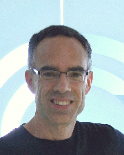

**Dr. Chris Chapman** is a Senior Quantitative Experience Researcher for the Google Cloud Platform, based in the Seattle office.

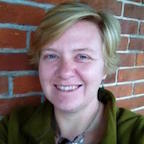

**Dr. Elea McDonnell Feit** is an Assistant Professor of Marketing at Drexel University and a Senion Fellow of the Wharton Customer Analytics Initiative.

### What is R?

“R is a language and environment for statistical computing and graphics.” http://www.r-project.org/about.html

R is:

- A programming language (not a “stats program'')
- An environment for writing code and handling data
- User extensible through add ons and custom code
- Open source and freely available
- Where new statistics and analytics innovation most often happen first

### What is R Not?

R is not:

- Intended for point-and-click usage
- Designed to hide complexity from the user
- Necessarily a fast or easy way to do something that is new to you

Like learning a non-computer human language, R takes time, practice, patience, and application to real problems.

### Why R?

If it's hard to learn, why is it worth it?

For some users, R is too much. If you don't like programming, you likely will not like R. On the other hand:

- R is optimized for working with data and statistics
- The programming language is relatively simple and flexible
- 1000s of people have contributed additions to R
- Once you have mastered something in R, it is easy to automate it and become more and more productive

And

- R skills are in very high demand

### Why NOT R?

- Full control == more complexity
- Steep learning curve
- Don't try to learn R when time is critical!

And perhaps most importantly:

- R is a programming language.
- If you have tried computer programming and didn't like it, you probably won't like R

### What do you need to use R?

At a minimum:

- R binaries from CRAN (Comprehensive R Archive Network)
- [http://cran.r-project.org]

Also recommended:

- RStudio IDE (integrated development environment)
- [http://www.rstudio.com]

RStudio is free and will make your life much easier! To use RStudio, first install R and then install RStudio separately.

### Now ...

**Make sure R and RStudio are up and running on your systems!**

Once it is working for everyone, we'll start with the language.